### Group Member: Claudia Yang, Coco Wu, Ethan Sun, Joyce Zhang

# Research Question

- Are US citizens more likely to be employed than those non-US citizens?

## Introduction

Motivation:

In exploring the intersection of citizenship status and employment in the United States, this research aims to tap into a crucial aspect of economic dynamics in the U.S.. The significance of citizenship status in shaping employment opportunities often influences access to legal work protections, job availability, and potentially impacting the broader economic landscape through labor market efficiency and policy formulation. Recent analyses conducted by the Center for Immigration Studies, reveals that while U.S. born employment has not rebounded to pre-COVID levels (2019), employment among immigrants has seen substantial growth. Specifically from 2019-2023, there has been an increase of 2.9 million immigrant workers compared to a decrease of 183,000 U.S. born workers. This divergence raises the question about the structure inequities and obstacles that different groups may face within the labor market.

Importance:

This is significant as it analyzes the impact of citizenship on employment opportunities–a fundamental aspect that shapes the economic landscape and individual lives of residents in the United States. By examining the employment rates of U.S. citizens as non-citizens, our study will look into the structural barriers that segment the labor market and the potential underutilization of a significant portion of the workforce. The findings could offer critical insights for policy makers and potentially drive reform in labor and immigration policies to harness a more inclusive and efficient employment system.

## Literature Review

- Where Are You From? Career Experiences of Non-US PhD Holders in the United States

This article by Dongbin Kim and Sehee Kim offers insight into the professional landscape faced by international scholars in the United States. They emphasize the relationship between citizenship status, country of origin, and career outcomes, THe study utilizes the 2013 National Science Foundation Survey of Doctorate recipients to analyze the career trajectories and dissatisfaction levels of non-US PhD holders compared to their US counterparts. The study reveals that non-US citizens often report lower career satisfaction and are less likely to hold supervisory positions. The disparity in holding supervisors roles diminishes when adjusted for demographic backgrounds, fields of study and years since graduation, displaying that factors beyond citizenship status influence career advancement. This directly ties into our research question as it showcases how citizenship and natural origin can impact not only employment status but also the quality and satisfaction of employment. It shows the importance of considering a range of factors when evaluating the employment disparities and suggests that citizenship status may not fully capture the complexity of employment experiences of the U.S. labor market.

- Are college graduate immigrants on work visas cheaper than natives?

Bagheri confronts the economic implications of hiring foreign professionals under H1-B and other work visas in the United States, exploring the wage disparities between immigrants and their U.S.-born counterparts. Analyzing data from the National Survey of College Graduates across several cycles from 2010 to 2017, the study finds that contrary to the common belief that immigrant workers are less expensive, those on temporary work visas actually earned a wage premium over U.S.-born citizens. Their wages increased from 15.6% in 2010 to 31.9% in 2017. This premium was pronounced from immigrants in English-speaking countries, those educated outside the U.S. and in fields such as computer science and engineering. HOwever, no significant wage differences were observed among those in certain other professions or among holders of doctoral and professional degrees. These findings display how employment rates and conditions of U.S. versus non-U.S. citizens by highlighting how immigration status intersects with wage dynamics. Thus pointing to the complexity of the labor market where citizenship and visa status can significantly influence economic outcomes. This study is able to challenge simplistic narratives around the economic roles of immigrant workers and suggests the need for nuanced policy approaches to skilled worker immigration.

- Right for the Job: Over-Qualified or Under-Skilled?

According to Glenda Quintini, in the OECD, approximately one in four workers is overqualified for their jobs, and about one in five is underqualified, with immigrants and new labor market entrants notably over-represented among the overqualified. This mismatch is not only a reflection of educational attainment but is also influenced by the actual skills possessed and required. Only 40% of overqualified workers in European countries feel equipped for more demanding tasks and a mere 12% of the under qualified feel they need more training. THis suggests a complex interplay between perceived and actual skill adequacy, influenced by various factors including job market dynamics and individual career paths. This studys\’s focus on the adaptability of job requirements and the recognition of non-formal and informal learning showcases the flexibility within the labor market to accommodate diverse skill sets–particularly for immigrants. Quinitini’s findings display how structural labor market conditions and recognition of qualifications impact employment outcomes. Thus arguing for a nuanced understanding of how qualifications, skills, and job requirements interact and shape labor market experiences–pointing towards the need for policies that enhance skill recognition and reduce qualification mismatches–especially among immigrants and non U.S. citizens.

- Putting Americans First: A Statistical Case for Encouraging Rather than Impeding and Devaluing US Citizenship

This article examines how naturalization significantly enhances the integration, success, and contribution of immigrants in the UNited States. It displays how naturalized citizens often achieve higher education levels, income, and homeownership rates that their native-born counterparts. The research highlights the critical role of naturalization in enabling immigrants to access better socioeconomic opportunities, thus reinforcing the argument that the path to citizenship is integral to strengthening natural cohesion and the overall prosperity of society. Additionally, the article discusses the adverse impacts of policies that restrict access to naturalization and permanent residency, particularly under the Trump administrations’ “America first” ideology. These policies not only complicate the naturalization process but also risk creating a disenfranchised subclass–especially among U.S.-born children of undocumented parents. By contrasting the Trump administration’s stance with the tangible benefits of naturalization and family reunification–the article challenged prevailing narratives that undermine family-based immigration. The analysis ties into our research by demonstrating the profound implications of citizenship status on employment and integration, offering insights into how legal frameworks and policies influence the economic trajectories of immigrants nad by extension the nation;s workforce dynamics.

- The Contribution of International Graduate Students to US Innovation

The study conducted by Chelleraj and et. al. quantifies the pivotal role of international graduate students in the U.S. innovation ecosystem. BY using a model of idea generation, their research concludes that a mere 10% increase in the enrollment of foreign graduate students catalyzes a substantial uplift in patent outputs, including a 4.5% increase in patent applications and enhancements of 6.8% and 5% in university and non-university patent grants, respectively, These findings not only showcase the contribution of international talent to the U.S. intellectual and technological advancement but also caution against the potential stifling of innovation through restrictive immigration policies. This research aligns with our research question by highlighting how immigration status intersects with capabilities in innovation and hence reinforcing the broader implications of immigration policies on national competitiveness.

- Immigrants in the US Labor Market

This article explores the dual impact of immigrants in the U.S. economy and shows the substantial benefits such as increased productivity, innovation, and cultural enrichment. These include the predominance of immigrants in low-wage jobs and their disproportionate use of public services relative to their tax contributions–which complicates their fiscal impact. Additionally, the economic benefits derived from immigration are unevenly distributed with native low-skilled workers facing potential wage suppression and poorer households benefiting less from cheaper immigrant-produced goods. THis analysis provides another layer of context to our research question by emphasizing how citizenship status influences employment opportunities and economic outcomes in a complex dynamic with broader socio economic and policy relationships.

- Migration and US Economic Competitiveness

Martin highlights widespread dissatisfaction with the current immigration framework, emphasizing the systemic issues such as the significant backlog for family reunification and the inadequate intake of highly skilled immigrants and temporary workers in sectors critical for innovation and competitiveness in a knowledge driven economy. He argues that the difficulty in quantifying the exact benefits and costs of immigration contributes the persistence of these policy challenges. This examination is critical in understanding the foundational effects of immigration on economic competitiveness, making it a significant contribution to our research. Martin’s analysis suggests that revising immigration policies to favor skilled workers could enhance the U.S.’s economic stance globally.

- The globalization of postsecondary education: The role of international students in the US higher education system

This research conducted by Bound and et. al. provides analysis for the substantial economic and educational impact of international students in the U.S. over the past four decades. Their study documents the significant increase in foreign student enrollment, which not only enhances the U.S. economy through substantial tuition revenue but also contributes to the global supply of skilled workers–particularly in STEM fields. The authors emphasize the vital role of U.S. visa policies in facilitating this influx, which allows international students to transition smoothly into the U.S. labor market and thus supporting sectors that are critical for innovation. This du=ynamic informs our research question through education and subsequent employment opportunities for international students and how they integrate into the U.S> labor market.

## Data

```python
# Import necessary packages
import numpy as np
import pandas as pd
import seaborn as sns
```

```python
# Import dataset
data = pd.read_csv(r'C:\Users\joyce\PycharmProjects\Econ220\usa_00004.csv')
```

The citizenship variable was cleaned and recoded into two main categories for analysis:

**U.S. Citizens**: Includes individuals born abroad to American parents or naturalized citizens.

**Non-Citizens**: Individuals not holding U.S. citizenship.

This recoding allows analysis of employment patterns among citizens versus non-citizens.

- EMPSTAT

The employment status variable was categorized into three distinct groups:

**Employed**: Individuals actively working.

**Unemployed**: Individuals actively seeking work but not currently employed.

**Not In Labor Force**: Individuals neither working nor actively seeking work.

These categories were recoded to compare labor market engagement across groups.

#### Data Cleaning Process

The above two variables, 'CITIZEN' and 'EMPSTAT', where a value of 0 indicates that the information is not available (N/A). To ensure the quality of our analysis, we remove all rows where either 'CITIZEN' or 'EMPSTAT' is 0. This process results in a dataset that excludes all entries with missing or unavailable status for these key demographic indicators. The cleaned dataset is then saved for further analysis.

```python
# Drop rows where either CITIZEN or EMPSTAT has a value of 0
cleaned_data = data[(data['CITIZEN'] != 0) & (data['EMPSTAT'] != 0)]
```

- SEX & Race

The gender variable (SEX) was recoded into meaningful categories (**Male and Female**). The race variable (RACE) was grouped into broader categories representing **White, Black, Asian, and Other racial groups**. These transformations enable comparison across key demographic factors.

- Sample Restriction

The sample restriction applied for **age limits** the dataset to individuals within the **legally defined working age in the United States**. Specifically, only individuals aged 14 and above are included, as this is the minimum legal age for employment. Additionally, the dataset excludes individuals aged 66 and older, aligning with the typical legal retirement age. This restriction ensures that the analysis focuses on those who are eligible to participate in the workforce, providing a clearer view of employment patterns within the legally working-age population.

```python
# Subset the dataset for legally working age (14 <= AGE < 66)
working_age_data = cleaned_data[(cleaned_data['AGE'] >= 14) & (data['AGE'] < 66)]
```

## Descriptive Statistics

```python
# Display information of the subset
working_age_data.info()
```

```
<class 'pandas.core.frame.DataFrame'>
Index: 2123378 entries, 108 to 14286946
Data columns (total 17 columns):
 #   Column    Dtype
---  ------    -----
 0   YEAR      int64
 1   SAMPLE    int64
 2   SERIAL    int64
 3   CBSERIAL  float64
 4   HHWT      float64
 5   CLUSTER   int64
 6   STRATA    int64
 7   GQ        int64
 8   PERNUM    int64
 9   PERWT     float64
 10  SEX       int64
 11  AGE       int64
 12  RACE      int64
 13  RACED     int64
 14  CITIZEN   float64
 15  EMPSTAT   int64
 16  EMPSTATD  int64
dtypes: float64(4), int64(13)
memory usage: 291.6 MB
```

```python
working_age_data.describe().round(2)
```

|  | YEAR | SAMPLE | SERIAL | CBSERIAL | HHWT | CLUSTER | STRATA | GQ | PERNUM | PERWT | SEX | AGE | RACE | RACED | CITIZEN | EMPSTAT | EMPSTATD |
| --- | --- | --- | --- | --- | --- | --- | --- | --- | --- | --- | --- | --- | --- | --- | --- | --- | --- |
| count | 2123378.00 | 2123378.00 | 2123378.00 | 2.521560e+05 | 2123378.00 | 2.123378e+06 | 2123378.00 | 2123378.00 | 2123378.00 | 2123378.00 | 2123378.00 | 2123378.00 | 2123378.00 | 2123378.00 | 824694.00 | 2123378.00 | 2123378.00 |
| mean | 1981.38 | 198141.77 | 410457.09 | 2.020001e+12 | 106.24 | 1.981385e+12 | 62125.18 | 1.09 | 1.97 | 107.13 | 1.51 | 37.42 | 2.09 | 211.30 | 2.45 | 1.74 | 17.48 |
| std | 17.50 | 1749.42 | 275052.42 | 2.059386e+06 | 49.81 | 1.749932e+10 | 349124.01 | 0.49 | 1.30 | 52.50 | 0.50 | 14.56 | 2.11 | 216.54 | 0.61 | 0.95 | 9.43 |
| min | 1970.00 | 197003.00 | 1.00 | 2.020000e+12 | 0.00 | 1.970000e+12 | 4.00 | 1.00 | 1.00 | 0.00 | 1.00 | 14.00 | 1.00 | 100.00 | 1.00 | 1.00 | 10.00 |
| 25% | 1970.00 | 197004.00 | 170572.00 | 2.020000e+12 | 100.00 | 1.970003e+12 | 46.00 | 1.00 | 1.00 | 100.00 | 1.00 | 25.00 | 1.00 | 100.00 | 2.00 | 1.00 | 10.00 |
| 50% | 1970.00 | 197004.00 | 373939.50 | 2.020001e+12 | 100.00 | 1.970006e+12 | 61.00 | 1.00 | 2.00 | 100.00 | 2.00 | 37.00 | 1.00 | 100.00 | 3.00 | 1.00 | 10.00 |
| 75% | 1990.00 | 199002.00 | 614492.00 | 2.020001e+12 | 100.00 | 1.990007e+12 | 66.00 | 1.00 | 2.00 | 100.00 | 2.00 | 49.00 | 2.00 | 200.00 | 3.00 | 3.00 | 30.00 |
| max | 2020.00 | 202001.00 | 1236879.00 | 2.020010e+12 | 3626.00 | 2.020012e+12 | 7030155.00 | 5.00 | 43.00 | 3626.00 | 2.00 | 65.00 | 9.00 | 990.00 | 3.00 | 3.00 | 30.00 |

In the summary statistics table looking at the working age data, there are a variety of variables that will help inform us of our reserach question. The data showcases data from the years 1970 to 2020, thus spanning 50 years of samples. When viewing the AGE variable, there is a mean age of 37.42 suggesting the dataset primarily includes young to middle-aged adults. EMPSTAT displays a mean of 1.74 and with 1 - unemployed, 2 = unemployed, 3 = Not in Labor Force, the mean suggests a higher proportion of employed individuals in the dataset.

```python
working_age_data[['SEX', 'AGE','RACE','CITIZEN','EMPSTAT']].describe().round(2)
```

|  | SEX | AGE | RACE | CITIZEN | EMPSTAT |
| --- | --- | --- | --- | --- | --- |
| count | 2123378.00 | 2123378.00 | 2123378.00 | 824694.00 | 2123378.00 |
| mean | 1.51 | 37.42 | 2.09 | 2.45 | 1.74 |
| std | 0.50 | 14.56 | 2.11 | 0.61 | 0.95 |
| min | 1.00 | 14.00 | 1.00 | 1.00 | 1.00 |
| 25% | 1.00 | 25.00 | 1.00 | 2.00 | 1.00 |
| 50% | 2.00 | 37.00 | 1.00 | 3.00 | 1.00 |
| 75% | 2.00 | 49.00 | 2.00 | 3.00 | 3.00 |
| max | 2.00 | 65.00 | 9.00 | 3.00 | 3.00 |

```python
# Create dummy variables for SEX
working_age_data.loc[:, 'Female'] = (working_age_data['SEX'] == 2).astype(int)  # 1 if Female
working_age_data.loc[:, 'Male'] = (working_age_data['SEX'] == 1).astype(int)    # 1 if Male
```

```python
# Create dummy variables for RACE
working_age_data.loc[:, 'White'] = (working_age_data['RACE'] == 1).astype(int)  # 1 if White
working_age_data.loc[:, 'Black'] = (working_age_data['RACE'] == 2).astype(int)  # 1 if Black/African American
working_age_data.loc[:, 'Asian'] = (working_age_data['RACE'].isin([4, 5, 6])).astype(int)  # 1 if Asian
working_age_data.loc[:, 'Other'] = (~working_age_data['RACE'].isin([1, 2, 4, 5, 6])).astype(int)  # 1 for Other races
```

```python
# Create dummy variables for CITIZEN
working_age_data.loc[:, 'Citizen'] = (working_age_data['CITIZEN'].isin([1, 2])).astype(int)  # 1 if citizen (born or naturalized)
working_age_data.loc[:, 'NonCitizen'] = (working_age_data['CITIZEN'] == 3).astype(int)      # 1 if non-citizen
```

```python
# Create dummy variables for EMPSTAT
working_age_data.loc[:, 'Employed'] = (working_age_data['EMPSTAT'] == 1).astype(int)        # 1 if employed
working_age_data.loc[:, 'Unemployed'] = (working_age_data['EMPSTAT'] == 2).astype(int)      # 1 if unemployed
working_age_data.loc[:, 'NotInLaborForce'] = (working_age_data['EMPSTAT'] == 3).astype(int) # 1 if not in labor force
```

```python
# Compute descriptive statistics for the selected dummy and other important columns
# Separate the statistics for clarity
sex_columns = ['Female', 'Male']
race_columns = ['White', 'Black', 'Asian', 'Other']
empstat_columns = ['Employed', 'Unemployed', 'NotInLaborForce']
citizenship_columns = ['Citizen', 'NonCitizen']

# Generate descriptive statistics for each group
sex_statistics = working_age_data[sex_columns].describe().round(2)
race_statistics = working_age_data[race_columns].describe().round(2)
empstat_statistics = working_age_data[empstat_columns].describe().round(2)
citizenship_statistics = working_age_data[citizenship_columns].describe().round(2)

# Print the statistics for each group
print("\n### Sex Statistics ###")
print(sex_statistics)

print("\n### Race Statistics ###")
print(race_statistics)

print("\n### Employment Status Statistics ###")
print(empstat_statistics)

print("\n### Citizenship Statistics ###")
print(citizenship_statistics)
```

```
### Sex Statistics ###
           Female        Male
count  2123378.00  2123378.00
mean         0.51        0.49
std          0.50        0.50
min          0.00        0.00
25%          0.00        0.00
50%          1.00        0.00
75%          1.00        1.00
max          1.00        1.00

### Race Statistics ###
            White       Black       Asian       Other
count  2123378.00  2123378.00  2123378.00  2123378.00
mean         0.72        0.09        0.09        0.10
std          0.45        0.28        0.29        0.29
min          0.00        0.00        0.00        0.00
25%          0.00        0.00        0.00        0.00
50%          1.00        0.00        0.00        0.00
75%          1.00        0.00        0.00        0.00
max          1.00        1.00        1.00        1.00

### Employment Status Statistics ###
         Employed  Unemployed  NotInLaborForce
count  2123378.00  2123378.00       2123378.00
mean         0.61        0.03             0.35
std          0.49        0.18             0.48
min          0.00        0.00             0.00
25%          0.00        0.00             0.00
50%          1.00        0.00             0.00
75%          1.00        0.00             1.00
max          1.00        1.00             1.00

### Citizenship Statistics ###
          Citizen  NonCitizen
count  2123378.00   2123378.0
mean         0.19         0.2
std          0.39         0.4
min          0.00         0.0
25%          0.00         0.0
50%          0.00         0.0
75%          0.00         0.0
max          1.00         1.0
```

The computed mean for dummy variables (e.g., Female, Black, Asian, Citizen, Employed) represents the proportion of individuals within each respective group in the sample. For binary dummy variables (coded as 0 or 1), a mean value close to 0 indicates few members in that group, while a mean value close to 1 indicates that the majority of the sample belongs to that group.

**Data Intrepretation** There appears to be predominantly individuals who identify as White with 72% of the people surveyed subsisting of this population in the sample set. Black populations consist of 9% of the sample size as does the Asian population also consists of 9% of the survey sample size. These groups are significantly less represented to the White population. The reminaing 10% accounts for individuals who do not identify with races specifed sperately in the dataset or who may identify as multiracial.

## Plots

```python
# Import packages for plot
import matplotlib.pyplot as plt
```

#### Plot1: Bar Plot - Comparing Employment for Citizens vs Non-Citizens

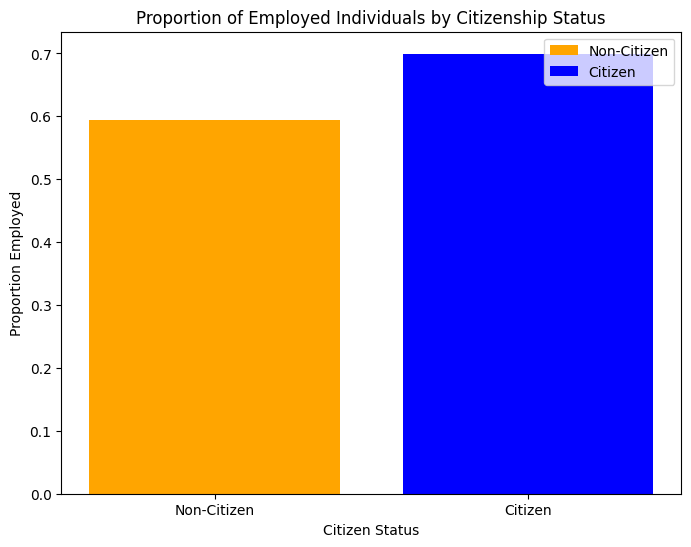

```python
# Compute the proportion of employed individuals by citizenship status
employment_summary = working_age_data.groupby('Citizen')['Employed'].mean().reset_index()
employment_summary.columns = ['Citizen_Status', 'Proportion_Employed']

# Map the coded integers to human-readable labels
employment_summary['Citizen_Status_Label'] = employment_summary['Citizen_Status'].map({1: 'Citizen', 0: 'Non-Citizen'})

# Create color mapping for the groups
colors = {'Citizen': 'blue', 'Non-Citizen': 'orange'}

# Plot with manually assigned colors
plt.figure(figsize=(8, 6))
bars = plt.bar(
    employment_summary['Citizen_Status_Label'],
    employment_summary['Proportion_Employed'],
    color=[colors[label] for label in employment_summary['Citizen_Status_Label']]
)

# Add custom legend
plt.legend(bars, ['Non-Citizen', 'Citizen'], loc='upper right')

# Add title, axis labels, and show the plot
plt.title('Proportion of Employed Individuals by Citizenship Status')
plt.ylabel('Proportion Employed')
plt.xlabel('Citizen Status')
plt.show()
```

We developed a bar chart that displays the proportion of employed individuals under citizen and Non-citizen status. From the output we can see a distinction of employement between individuals of different citizenship status. Under 60% of Non-citizens are employed, whereas approximately 70% of citizens are employed. In general, citizens are more likely to be employed compared to Non-citizens.

#### Plot2: Stacked Bar Chart - Employment Breakdown by Citizenship

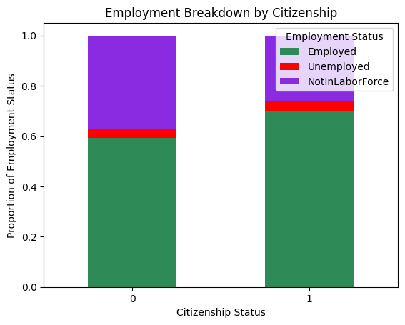

```python
import matplotlib.pyplot as plt

# Group by 'Citizenship' and calculate mean values for employment status
grouped_data = working_age_data.groupby('Citizen')[['Employed', 'Unemployed', 'NotInLaborForce']].mean()

# Plotting the stacked barplot with the updated original data
grouped_data.plot(kind='bar', stacked=True, color=['seagreen', 'red', 'blueviolet'])
plt.xlabel('Citizenship Status')
plt.ylabel('Proportion of Employment Status')
plt.title('Employment Breakdown by Citizenship')
plt.legend(title='Employment Status')
plt.xticks(rotation=0)  # Ensures x-axis labels are horizontal for better readability
plt.show()
```

```python
print(working_age_data['CITIZEN'])
```

```
108         3.0
150         3.0
159         2.0
179         2.0
201         2.0
           ...
14286782    2.0
14286919    2.0
14286944    2.0
14286945    2.0
14286946    2.0
Name: CITIZEN, Length: 2123378, dtype: float64
```

#### Plot3: Pivot Table - Employment Proportions by Citizenship, Gender, and Race

We include a pivot table comparing the employment status of male and female individuals of different races divided by their citizenship status. It is generally observed that demographics with citizenship have higher proportiongs of those employed, and demographics without citizenship tend to have a higher proportion of individuals not in the labor force.

```python
# Map gender and race to meaningful labels
working_age_data['Gender_Label'] = working_age_data['SEX'].map({1: 'Male', 2: 'Female'})
working_age_data['Race_Label'] = working_age_data['RACE'].map({
    1: 'White',
    2: 'Black',
    3: 'Asian',
    4: 'Other'
})

# Group by Citizen, Gender, Race, and Employment Status
employment_counts = working_age_data.groupby(['Citizen', 'Gender_Label', 'Race_Label', 'EMPSTAT']).size().reset_index(name='count')

# Map Employment Status codes to human-readable labels
employment_counts['Employment_Status_Label'] = employment_counts['EMPSTAT'].map({
    1: 'Employed',
    2: 'Unemployed',
    3: 'Not In Labor Force'
})

# Create pivot table with multi-index for visualization
pivot_table = employment_counts.pivot_table(
    index=['Citizen', 'Gender_Label', 'Race_Label'],
    columns='Employment_Status_Label',
    values='count',
    aggfunc='sum',
    fill_value=0
)

# Normalize the pivot table to proportions for comparison
pivot_table_percentage = pivot_table.div(pivot_table.sum(axis=1), axis=0)

# Add a "Total" column (sum of all employment statuses for each row)
pivot_table_percentage['Total'] = pivot_table_percentage.sum(axis=1)

# Display the modified pivot table with the "Total" column
print(pivot_table_percentage)
```

```
Employment_Status_Label          Employed  Not In Labor Force  Unemployed  \
Citizen Gender_Label Race_Label
0       Female       Asian       0.388652            0.567128    0.044219
                     Black       0.469728            0.487140    0.043133
                     Other       0.523116            0.444768    0.032116
                     White       0.426782            0.548701    0.024517
        Male         Asian       0.640973            0.292958    0.066069
                     Black       0.655474            0.297637    0.046889
                     Other       0.692638            0.276649    0.030713
                     White       0.769732            0.198666    0.031603
1       Female       Asian       0.603306            0.342516    0.054178
                     Black       0.699959            0.253886    0.046155
                     Other       0.676813            0.292310    0.030877
                     White       0.572820            0.395622    0.031558
        Male         Asian       0.739056            0.197425    0.063519
                     Black       0.740054            0.201551    0.058395
                     Other       0.807372            0.161211    0.031417
                     White       0.800031            0.162037    0.037932

Employment_Status_Label          Total
Citizen Gender_Label Race_Label
0       Female       Asian         1.0
                     Black         1.0
                     Other         1.0
                     White         1.0
        Male         Asian         1.0
                     Black         1.0
                     Other         1.0
                     White         1.0
1       Female       Asian         1.0
                     Black         1.0
                     Other         1.0
                     White         1.0
        Male         Asian         1.0
                     Black         1.0
                     Other         1.0
                     White         1.0
```

## Hypothesis Testing

- Null Hypothesis H<sub>0</sub>: There is no difference in proportion of employment in US citizens and non-US citizens in the United States
- Alternative Hypothesis H<sub>a</sub>: There is a difference in proportion of employment in US citizens and non-US citizens in the United States

```python
import numpy as np
import pandas as pd
import seaborn as sns
from scipy.stats import ttest_ind
from statsmodels.stats.proportion import proportions_ztest
```

### Hypothesis Test 1: Difference in proportion of employment by race: White Citizen vs. White Non-citizen

- Null Hypothesis H<sub>0</sub>: There is no difference in proportion of employment in white US citizens and white non-US citizens in the United States
- Alternative Hypothesis H<sub>a</sub>: There is a difference in proportion of employment in white US citizens and white non-US citizens in the United States

```python
#Distribution of employment status by white citizen and white non-citizen
df = pd.DataFrame(working_age_data)
df['white_citizen_status'] = df.apply(
    lambda row: 'white-citizen' if row['RACE'] == 1 and row['CITIZEN'] in [1, 2]
    else 'white-non-citizen' if row['RACE'] == 1 and row['CITIZEN'] == 3
    else None,
    axis=1)

df['employment'] = df.apply(
    lambda row: 'employed' if row['EMPSTAT'] == 1
    else 'not-employed' if row['EMPSTAT']in [2]
    else None,
    axis=1)

pd.crosstab(df['white_citizen_status'], df['employment'], margins=True)
```

| employment white_citizen_status | employed | not-employed | All |
| --- | --- | --- | --- |
| white-citizen | 137706 | 6990 | 144696 |
| white-non-citizen | 112176 | 8953 | 121129 |
| All | 249882 | 15943 | 265825 |

```python
#Test of difference in proportions of the employment of white-citizens versus employment of white non-citizens
test_pro_gen = proportions_ztest([137706,112176], [144696, 121129])
print('T-Stat: ', round(test_pro_gen[0], 4))
print('P-Value: ', round(test_pro_gen[1], 4))
```

```
T-Stat:  27.6897
P-Value:  0.0
```

The p-value of 0.0 represents an incredibly small value, that would definitely be below the threshold of 5%. There is a statistically significant difference in proportions of employment between white citizens and white non-citizens. We reject the Null Hypothesis.

### Hypothesis Test 2: Difference in proportion of employment by race: Black Citizen vs. Black Non-citizen

- Null Hypothesis H<sub>0</sub>: There is no difference in proportion of employment in black US citizens and black non-US citizens in the United States
- Alternative Hypothesis H<sub>a</sub>: There is a difference in proportion of employment in black US citizens and black non-US citizens in the United States

```python
#Distribution of employment status by black citizen and black non-citizen
df = pd.DataFrame(working_age_data)
df['black_citizen_status'] = df.apply(
    lambda row: 'black-citizen' if row['RACE'] == 2 and row['CITIZEN'] in [1, 2]
    else 'black-non-citizen' if row['RACE'] == 2 and row['CITIZEN'] == 3
    else None,
    axis=1)

df['employment'] = df.apply(
    lambda row: 'employed' if row['EMPSTAT'] == 1
    else 'not-employed' if row['EMPSTAT']in [2]
    else None,
    axis=1)

pd.crosstab(df['black_citizen_status'], df['employment'], margins=True)
```

| employment black_citizen_status | employed | not-employed | All |
| --- | --- | --- | --- |
| black-citizen | 19810 | 1430 | 21240 |
| black-non-citizen | 17015 | 1859 | 18874 |
| All | 36825 | 3289 | 40114 |

```python
#Test of difference in proportions of the employment of black-citizens versus employment of black non-citizens
test_pro_gen = proportions_ztest([19810,17015], [21240, 18874])
print('T-Stat: ', round(test_pro_gen[0], 4))
print('P-Value: ', round(test_pro_gen[1], 4))
```

```
T-Stat:  11.3575
P-Value:  0.0
```

The p-value of 0.0 here also represents an incredibly small value, which would definitely be below the threshold of 5%. There is a statistically significant difference in proportions of employment between black citizens and black non-citizens as well in terms of employment status in United States. We reject the Null Hypothesis.

- Null Hypothesis H<sub>0</sub>: There is no difference in proportion of employment in Asian US citizens and Asian non-US citizens in the United States
- Alternative Hypothesis H<sub>a</sub>: There is a difference in proportion of employment in Asian US citizens and Asian non-US citizens in the United States

```python
#Distribution of employment status by Asian citizen and Asian non-citizen
df = pd.DataFrame(working_age_data)
df['asian_citizen_status'] = df.apply(
    lambda row: 'asian-citizen' if row['RACE'] == 3 and row['CITIZEN'] in [1, 2]
    else 'asian-non-citizen' if row['RACE'] == 3 and row['CITIZEN'] == 3
    else None,
    axis=1)

df['employment'] = df.apply(
    lambda row: 'employed' if row['EMPSTAT'] == 1
    else 'not-employed' if row['EMPSTAT']in [2]
    else None,
    axis=1)

pd.crosstab(df['asian_citizen_status'], df['employment'], margins=True)
```

| employment asian_citizen_status | employed | not-employed | All |
| --- | --- | --- | --- |
| asian-citizen | 1518 | 133 | 1651 |
| asian-non-citizen | 1936 | 172 | 2108 |
| All | 3454 | 305 | 3759 |

```python
#Test of difference in proportions of the employment of asian-citizens versus employment of asian non-citizens
test_pro_gen = proportions_ztest([1518,1936], [1651, 2108])
print('T-Stat: ', round(test_pro_gen[0], 4))
print('P-Value: ', round(test_pro_gen[1], 4))
```

```
T-Stat:  0.1155
P-Value:  0.908
```

## References

Camarota, Steven A. "Most Employment Growth Since Pandemic Has Gone to Immigrants." Center for Immigration Studies, 10 June 2024, cis.org/Camarota/Most-Employment-Growth-Pandemic-Has-Gone-Immigrants.

Kim, D. ., & Kim, S. (2022). Where Are You From? Career Experiences of Non-US PhD Holders in the United States. International Higher Education, (111), 23–24. Retrieved from https://ejournals.bc.edu/index.php/ihe/article/view/15337

Bagheri, O. Are College Graduate Immigrants on Work Visa Cheaper Than Natives?. J Labor Res 44, 228–260 (2023). https://doi.org/10.1007/s12122-023-09349-2

Quintini, G. (2011), "Right for the Job: Over-Qualified or Under-Skilled?", OECD Social, Employment and Migration Working Papers, No. 120, OECD Publishing, Paris, https://doi.org/10.1787/5kg59fcz3tkd-en.

https://www.oecd-ilibrary.org/social-issues-migration-health/right-for-the-job_5kg59fcz3tkd-en

Kerwin, D., & Warren, R. (2019). Putting Americans First: A Statistical Case for Encouraging Rather than Impeding and Devaluing US Citizenship. Journal on Migration and Human Security, 7(4), 108-122. https://doi.org/10.1177/2331502419894286

Chellaraj, G., Maskus, K.E. and Mattoo, A. (2008), The Contribution of International Graduate Students to US Innovation. Review of International Economics, 16: 444-462. https://doi.org/10.1111/j.1467-9396.2007.00714.x

Orrenius, P., Zavodny, M. (2014). Immigrants in the US Labor Market. In: Payan, T., de la Garza, E. (eds) Undecided Nation. Immigrants and Minorities, Politics and Policy, vol 6. Springer, Cham. https://doi.org/10.1007/978-3-319-06480-2_9

Martin, Philip L. "Migration and US Economic Competitiveness." Transnational Press London, Transnational Press, 2013. Labor Relations, Migration Studies, Ethnic Minorities Studies, Socio-Economic Research.https://www.ceeol.com/search/article-detail?id=480188

Bound J, Braga B, Khanna G, Turner S. The globalization of postsecondary education: The role of international students in the US higher education system. J Econ Perspect. 2021 Winter;35(1):163-184. doi: 10.1257/jep.35.1.163. PMID: 37786787; PMCID: PMC10544708.